# Introduction to Spatial Analysis in R

Vector data and simple features

Roozbeh Valavi, Jutta Beher and David Wilkinson

23/07/2019

# Vector data and features

A feature is thought of as a thing, or an object in the real world, such as a building or a tree. As is the case with *objects*, they often consist of other objects. This is the case with features too: **a set of features can form a single feature**. A forest stand can be a feature, a forest can be a feature, a city can be a feature (by Edzer Pebesma).

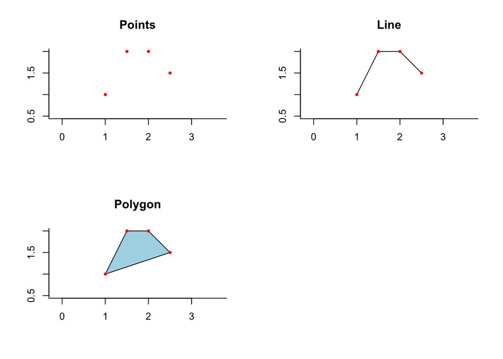

# Simple features in R

The definition of **simple features** in [wikipedia](https://en.wikipedia.org/wiki/Simple_Features).

[figure not shown]

I highly recommed reading [the simple feature web page](https://r-spatial.github.io/sf/articles/sf1.html).

## sf package

Ths `sf` package provides *simple feature access* for R. The `sf` object is a `data.frame` with a *geometry list-column*. It supports different format and spatial references since it is connected to **GDAL** and **PROJ**.

```r
# install.packages("sf")
library(sf)
```

# Reading and converting data to sf

You can read files directly to sf or convert them from other object types (e.g. `data.frame` or `sp` objects).

Now, we can read a polygon map of Australia in **shapefile (.shp)**.

```
## Simple feature collection with 8 features and 4 fields
## geometry type:  POLYGON
## dimension:      XY
## bbox:           xmin: -2063975 ymin: -4965263 xmax: 1891143 ymax: -1285856
## epsg (SRID):    NA
## proj4string:    +proj=lcc +lat_1=-18 +lat_2=-36 +lat_0=0 +lon_0=134 +x_0=0 +y_0=0 +ellps=GRS80 +units=m +no_defs
##   STATE                    STATENAME SHAPE_Leng  SHAPE_Area
## 1     9            Western Australia 102.585497 227.4586760
## 2     5                   Queensland  78.230893 151.7205320
## 3     6              South Australia  61.940128  91.7623310
## 4     8                     Victoria  35.336464  22.9619050
## 5     1 Australian Capital Territory   2.757198   0.2338955
## 6     7                     Tasmania  21.742202   7.0119035
## 7     3              New South Wales  52.471221  76.6085725
## 8     4           Northern Territory  67.244892 115.0931295
##                         geometry
## 1 POLYGON ((-869275 -1649846,...
## 2 POLYGON ((1224467 -1789526,...
## 3 POLYGON ((-494224 -2961045,...
## 4 POLYGON ((643286.2 -3849372...
## 5 POLYGON ((1368783 -4037628,...
## 6 POLYGON ((1166744 -4924361,...
## 7 POLYGON ((1587643 -3346985,...
## 8 POLYGON ((285958.2 -1394759...
```

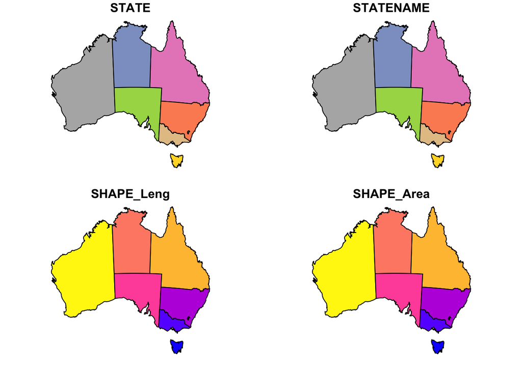

```r
states <- st_read("data/Australia/Australia_proj.shp")
states

plot(states)

# plot only the geometry
plot(st_geometry(states))
```

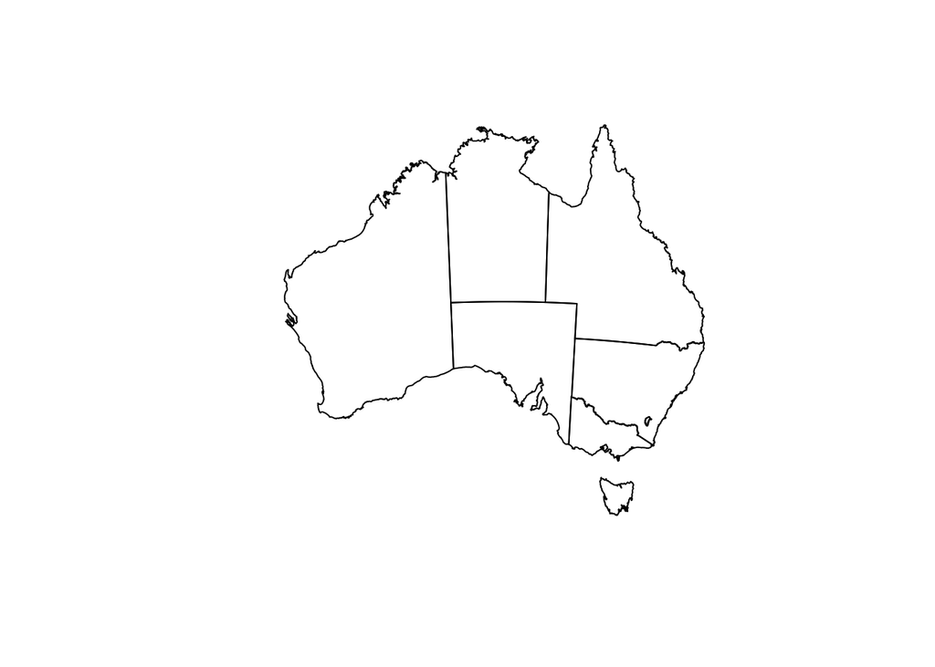

```r
# plot only the geometry
plot(st_geometry(states))
```

Here we want to read **koala.csv** file into R and convert it to `sf` object. This file contains *longitude* and *latitude* columns that we can use to create `sf` object.

```r
# reading csv file
koala <- read.csv("data/koala.csv")
head(koala) # see the first few rows
```

```
##           Genus                Species Longitude  Latitude
## 1 Phascolarctos Phascolarctos cinereus  152.7297 -30.18316
## 2 Phascolarctos Phascolarctos cinereus  151.8413 -32.79279
## 3 Phascolarctos Phascolarctos cinereus  152.7621 -30.23195
## 4 Phascolarctos Phascolarctos cinereus  138.7290 -34.94308
## 5 Phascolarctos Phascolarctos cinereus  153.5165 -28.58857
## 6 Phascolarctos Phascolarctos cinereus  153.2155 -27.49284
```

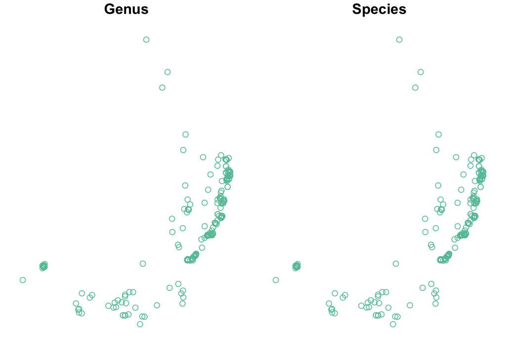

```r
# convert to sf
koala_sf <- st_as_sf(koala, coords = c("Longitude", "Latitude"), crs = 4326)

plot(koala_sf)
```

## Import data form packages

We can use **rworldmap** package to download the bo9undary map of the world. This packae provides the `SpatialPolygonsDataFrame` object of the world’s countries. We can convert it to `sf`. For this purpose we use **dplyr** package and its *piping* functionality to simplify the code!  
Remember to load **dplyr** or **tidyverse** package.

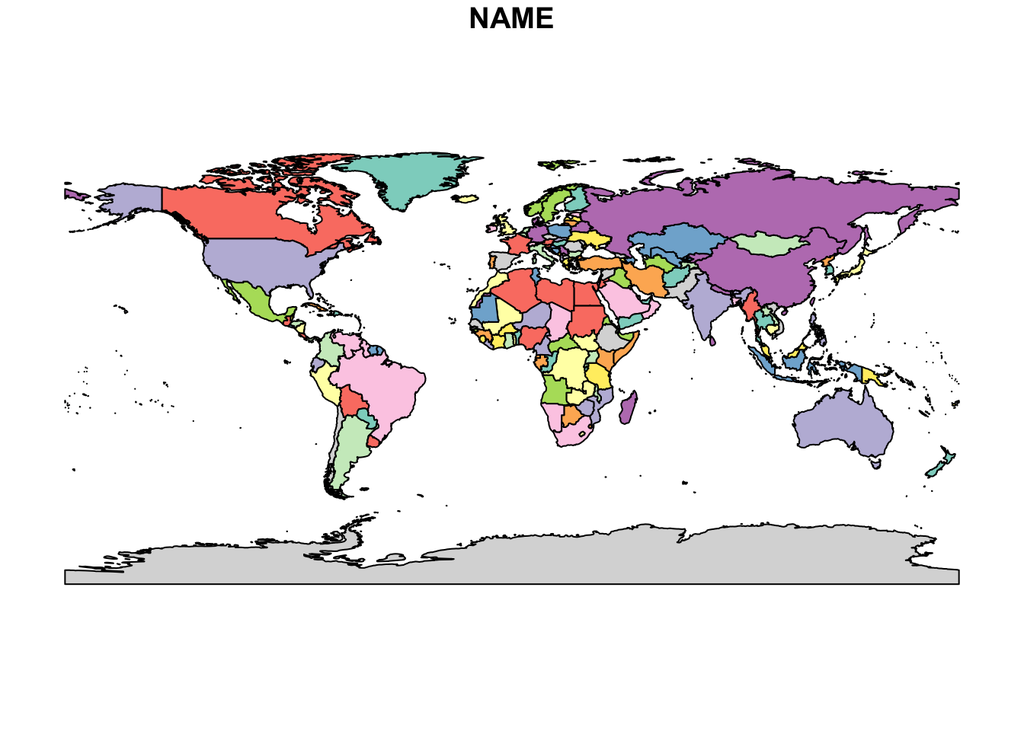

```r
library(rworldmap)
library(tidyverse)

wmap <- rworldmap::getMap(resolution = "low")  %>% # this is SpatialPolygonDataFrame
  st_as_sf()

plot(wmap["NAME"])
```

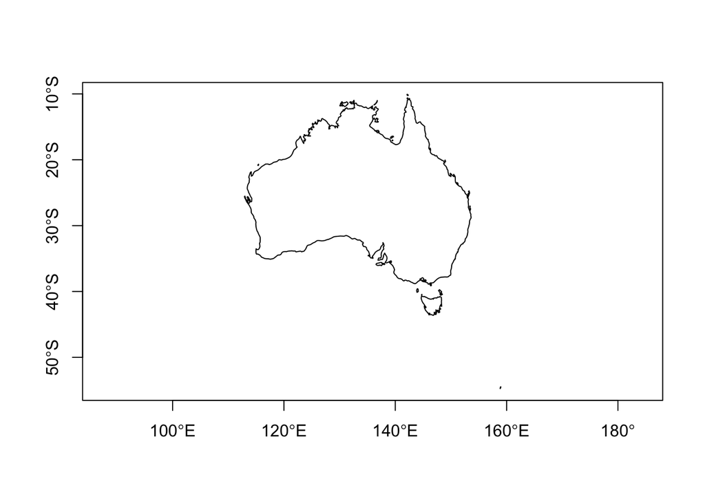

```r
# filter Australia by dplyr
australia <- wmap %>%
  filter(NAME == "Australia")

# plot only the geomety of asutalia
plot(australia$geometry, axes = TRUE)
```

We can get the cities of Australia from `maps` package.

```r
library(maps)

data(world.cities)
head(world.cities)
```

```
##                 name country.etc   pop   lat  long capital
## 1 'Abasan al-Jadidah   Palestine  5629 31.31 34.34       0
## 2 'Abasan al-Kabirah   Palestine 18999 31.32 34.35       0
## 3       'Abdul Hakim    Pakistan 47788 30.55 72.11       0
## 4 'Abdullah-as-Salam      Kuwait 21817 29.36 47.98       0
## 5              'Abud   Palestine  2456 32.03 35.07       0
## 6            'Abwein   Palestine  3434 32.03 35.20       0
```

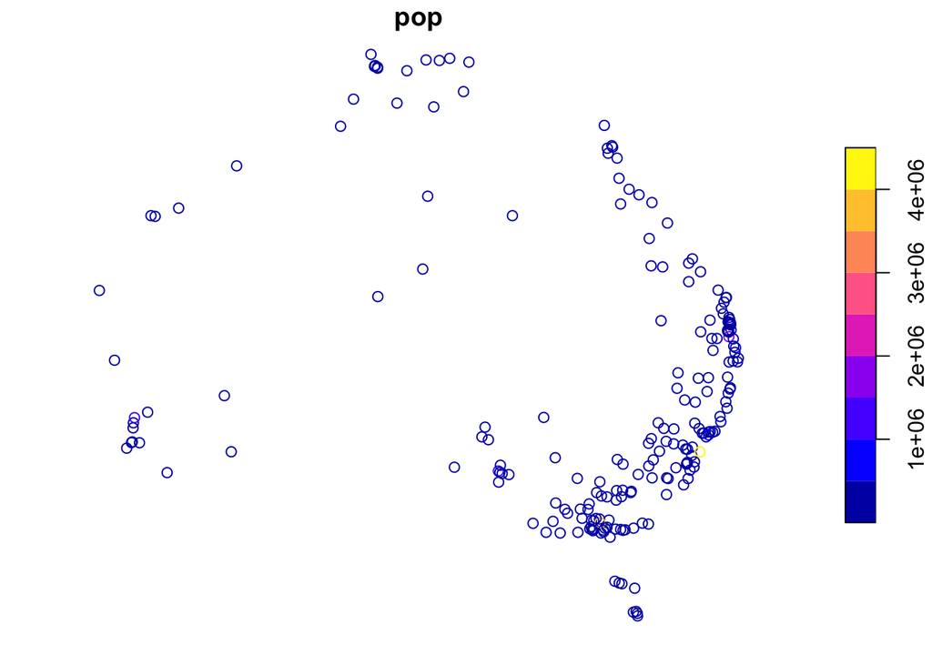

```r
cities <- st_as_sf(world.cities, coords = c("long", "lat"), crs = 4326) %>%
  filter(country.etc == "Australia")

plot(cities["pop"])
```

Why they are all the same colour?

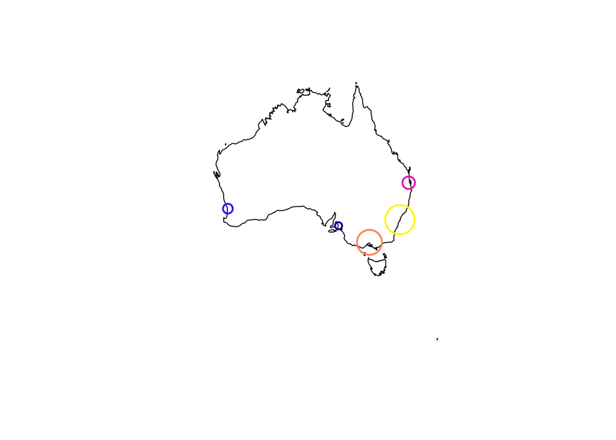

```r
# filter cities with a population over 1 million
big_cities <- filter(cities, pop > 1e6)

plot(australia$geometry)
plot(big_cities["pop"], cex = big_cities$pop / 1e6, lwd = 2, add = TRUE)
```

# Transform coordinate reference system

Now, we want to put the `koala_sf` on top of `states` map to see where koalas occur!

Check the coordinate reference of both maps! Are they the same?

```r
st_crs(states)
```

```
## Coordinate Reference System:
##   No EPSG code
##   proj4string: "+proj=lcc +lat_1=-18 +lat_2=-36 +lat_0=0 +lon_0=134 +x_0=0 +y_0=0 +ellps=GRS80 +units=m +no_defs"
```

```r
st_crs(koala_sf)
```

```
## Coordinate Reference System:
##   EPSG: 4326
##   proj4string: "+proj=longlat +datum=WGS84 +no_defs"
```

Two map layers should have the same spatial reference to be plotted on the correct location relative to each other. For this, we need to change `koala_sf` to be the same as `states` or vice versa.

Notice, the `crs` argument acsepts the [`EPSG`](https://support.esri.com/en/technical-article/000002814) code as well.

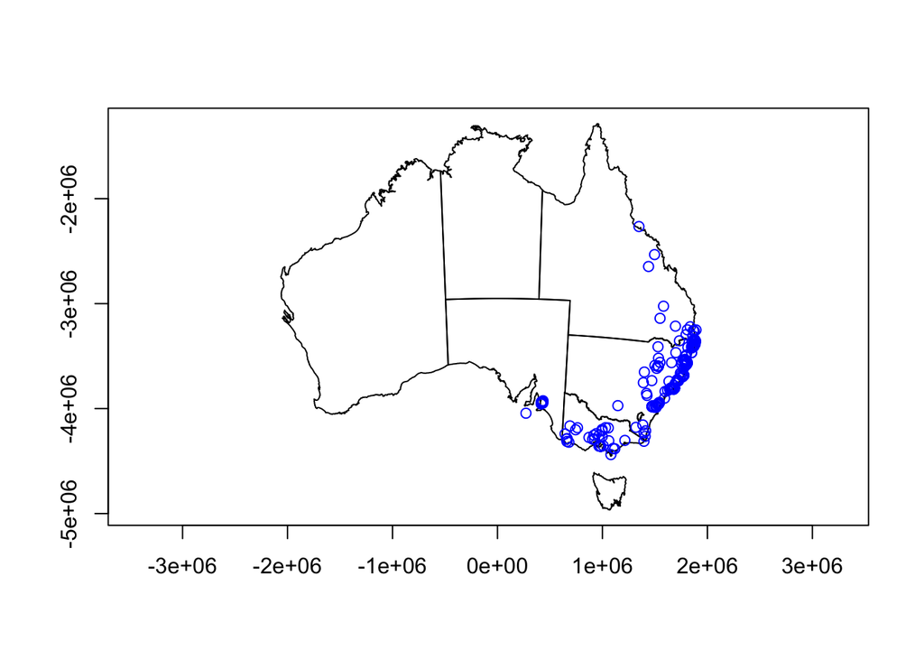

```r
# change the projection
koala_proj <- st_transform(koala_sf, crs = 3112)
# or
koala_proj <- st_transform(koala_sf, crs = st_crs(states))

# plot both layers
plot(st_geometry(states), axes = TRUE)
plot(koala_proj, col = "blue", add = TRUE)
```

# Challenge one

Directory of the data:  
`data/Australia/Australia_proj.shp`  
`data/koala.csv`

# Geometric operations

## Cropping sf

You can clip the **sf** object by another **sf** object or an `extent` object. The `extent` object can come from a layer (`st_bbox` for sf and `extent` for rasters) or we can draw one by `drawExtent` function in the **raster** package. First, you need to plot a map, then use run this function. For drawing the extent you should click on two points in the plotted map.

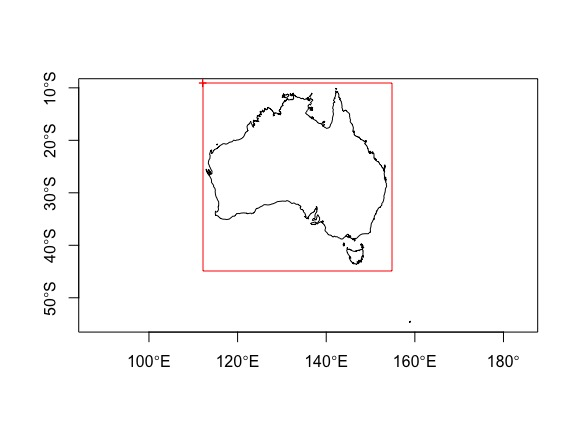

```r
library(raster)

# first plot the map
plot(australia$geometry, axes = TRUE)
# draw extent manually
ext <- drawExtent()
```

Now, you can use this object to clip a vector layer.

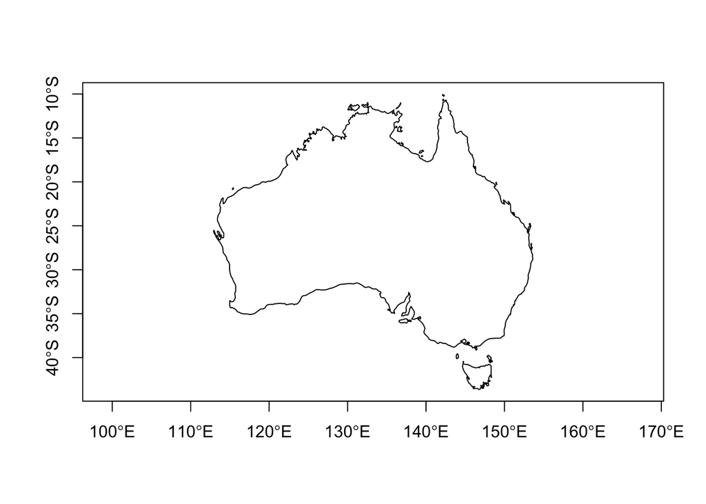

```r
australia_clip <- st_crop(australia, ext)
plot(australia_clip$geometry, axes = TRUE)
```

## Buffer and join

In many cases, you need to specify a zone around your map features. We can do this with *buffer* function in GIS and R. In many GIS software, the distance you specify for your buffers is in the unit of the input features (e.g. degree for the *latlong* coordinates and meters for *Lambert* or *UTM*), with an exception of `buffer` function in `raster` package.

Here we use `koala_proj` object which is in the **Lambert** coordinate system, so the unit is in metres. The `st_buffer` is the function we need here.

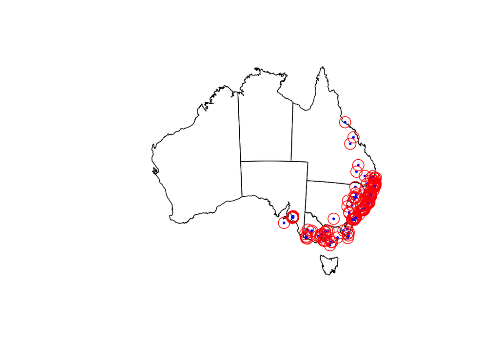

```r
buf <- st_buffer(koala_proj, 1e5)

plot(st_geometry(states))
plot(st_geometry(koala_proj), col = "blue", pch = 16, cex = 0.5, add = TRUE)
plot(st_geometry(buf), border = "red", add = TRUE)
```

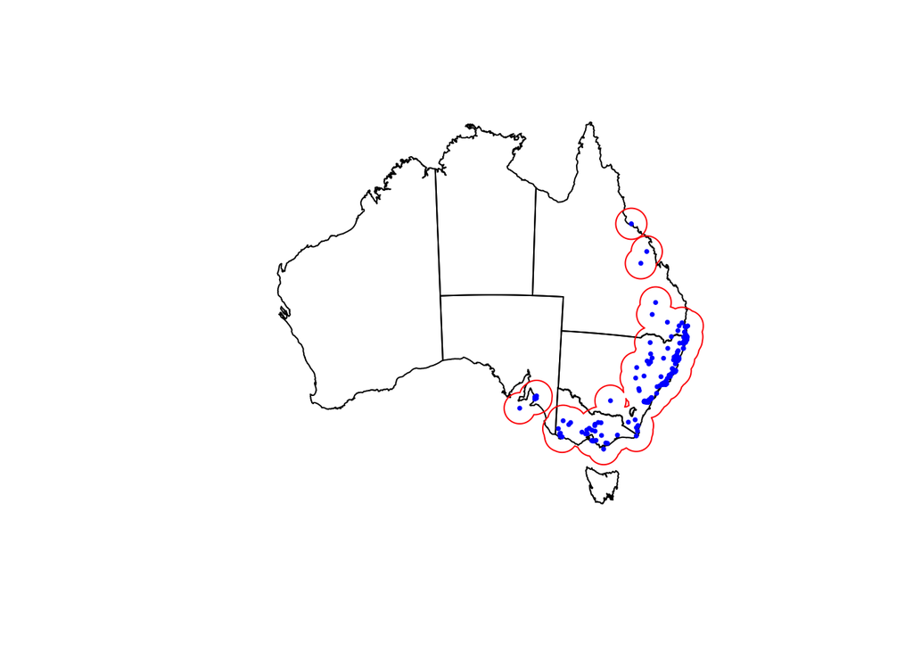

```r
buf <- st_buffer(koala_proj, 1.5e5) %>%
  st_union()

plot(st_geometry(states))
plot(st_geometry(koala_proj), col = "blue", pch = 16, cex = 0.5, add = TRUE)
plot(st_geometry(buf), border = "red", add = TRUE)
```

## Spatial join and intersection

Imagine you want to check how many of your koala points fall in each state. This can be done by `st_intersection` function. Notice that `st_intersects` function is a similar function, but *it does not return a spatial object*. With this function, the attribute of the second layer will be joined to the first layer where they have a spatial intersection. This is also called **spatial join** in GIS.

```r
koala_states <- st_intersection(koala_proj, states)

table(koala_states$STATENAME)
```

```
##
## Australian Capital Territory              New South Wales
##                            0                          181
##           Northern Territory                   Queensland
##                            0                           16
##              South Australia                     Tasmania
##                           14                            0
##                     Victoria            Western Australia
##                           31                            0
```

There are a lot of other geometric operations and handy functions to check the topologic relationship of simple features in **sf** package. To see more examples see [the sf package vignettes](https://cran.r-project.org/web/packages/sf/vignettes/sf3.html).

## Nearest distance

Spatial distance is a very important functionality in spatial analysis. Calculating the distance between features is very easy in GIS. Here we want to calculate the distance between the koala points and Australia coastline.

First, we need to convert the Australia map to line object, then calculate the points to the line. This is because the distance of the points to a polygon that contains them is zero. We can do this by `st_cast` function.

To calculate the spatial distance of the points to the line, `st_distance` function is used. This function returns a *dense distance matrix* that shows the pairwise distance of every single feature in both datasets. The output object would be in `units` so we can convert it to numeric.

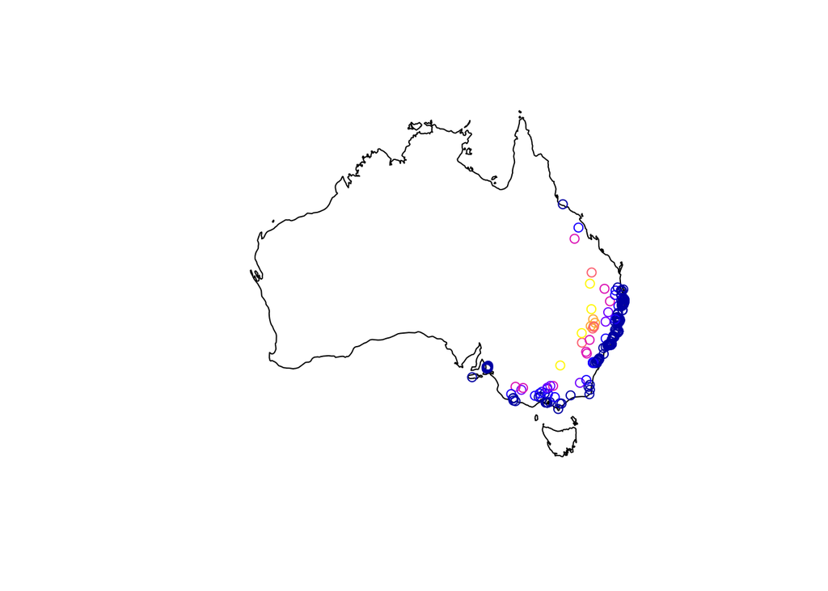

```r
# change polygon to line
aus_line <- st_cast(australia_clip, "MULTILINESTRING")

# calculate distance and save it in coastdist column
koala_sf$coastdist <- as.numeric(st_distance(koala_sf, aus_line))

plot(australia_clip$geometry)
plot(koala_sf["coastdist"], add = TRUE)
```

Here, the distance matrix is a `[250 x 1]` matrix (250 koala points and 1 line of coastline). In the cases where there are more several features in both layers, you need to calculate the `min` of each row of the output matrix (e.g. with `apply` function).

When you want to calculate the nearest distance of every feature in the same layer, you need to repeat the same layer in the `st_distance` function twice and then calculate the minimum distance. But here is not that easy! Because the nearest distance of every object in the same layer would be itself *i.e. the min distance for all of the features would be zero*. So, you need to discard the self-distance in the calculating minimum function. You can use the following function to do that. You might be able to find an easier or more efficient way to do that.

```r
koala_dist <- st_distance(koala_proj, koala_proj)
dim(koala_dist) # dimention of the dist matrix
```

```
## [1] 250 250
```

```r
koala_dist[1:5, 1:5]
```

```
## Units: [m]
##             [,1]      [,2]        [,3]    [,4]      [,5]
## [1,]       0.000  298613.7    6173.952 1404940  190336.9
## [2,]  298613.686       0.0  294356.980 1229357  487957.8
## [3,]    6173.952  294357.0       0.000 1405478  194075.2
## [4,] 1404940.357 1229357.4 1405478.023       0 1552826.2
## [5,]  190336.917  487957.8  194075.206 1552826       0.0
```

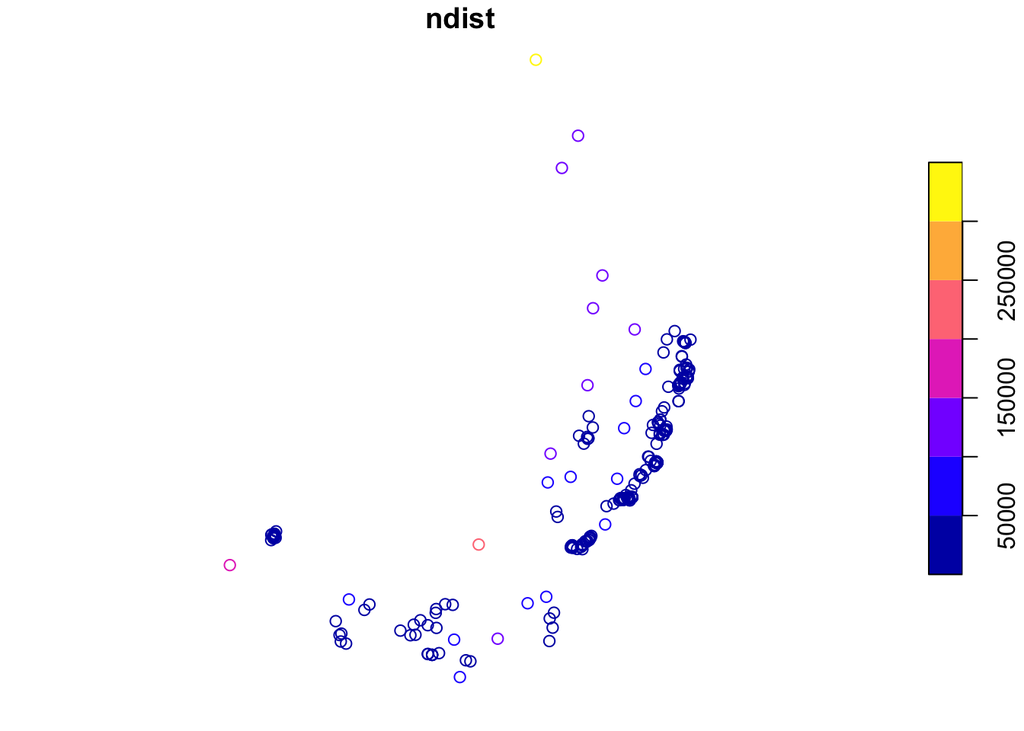

```r
# function to calculate min distance excluding the self-distance
mindist <- function(x) {
  mindis <- vector(mode = "numeric", length = nrow(x))
  for(i in 1:nrow(x)){
    mindis[i] <- min(x[i, -i])
  }
  return(mindis)
}

# calculate min distance and save it in ndist column
koala_proj$ndist <- mindist(koala_dist)

plot(koala_proj["ndist"])
```

# Write spatial data

To write your spatial vector data in your hard disk, you can use `st_write` function.

Here we write the `koala_proj` data to [`GeoPackage`](https://www.geopackage.org/) format. **GeoPackage** is an OGC standard and open format for transferring geospatial information. It is platform-independent, portable, and a compact format.

The old and familiar `shapefile` format has some drawbacks. For instance:

1. It stores in several individual files in hard disk
2. Size limitation to 2GB
3. Column names are limited to 12 characters

```r
st_write(koala_proj, "data/koala_projected.gpkg")
```

You can read `.gpkg` format the same way you read `.shp` files (with `st_read` function). **GeoPackage** is supported by **GDAL**, it means you can read and write them in all (updated) GIS software like **QGIS**.

# Challenge two

Load the city maps and calculate the nearest straight distance to the coastline of the cities with 0.5 m population and plot the distance. Then save the output layer in **GeoPackage**.